# PA1_template.Rmd

Anna_Perelman

Tuesday, August 12, 2014

## Loading the data

Let’s set the working directory.

After that we load the data using read.csv() function.

```r
setwd("D:/Education/Coursera/Data Science/Reproducible Research/HW/RepData_PeerAssessment1")
my_data<-read.csv("activity.csv",colClasses = c(steps="numeric",date="character", interval="numeric"))
```

Now let’s build the histogram of the total number of steps taken each day. For this purpose we need first to create a data frame steps_dates where the total number of steps is summarized for each date. Here is the code for this function:

```r
dates<-unique(my_data[,2])
steps_per_day<-function(dates_vector){
        length_dates<-length(dates)
        my_data_records<-nrow(my_data)
        steps_vector<-numeric()
        steps_date<-data.frame()
        for(i in 1:length_dates){
                steps_num<-0
                for(j in 1:my_data_records){
                        if(dates[i]==my_data[j,2]){
                                if(is.na(my_data[j,1])){
                                        next_steps_value<-0
                                }
                                else{
                                        next_steps_value<-as(my_data[j,1],"numeric")
                                }
                                steps_num<-steps_num+next_steps_value
                        }
                }
                steps_vector<-c(steps_vector,steps_num)
        }
        steps_date<-cbind(dates=dates_vector,steps=steps_vector)
        steps_date
}
steps_date<-steps_per_day(dates)
```

Now let’s build the histogram:

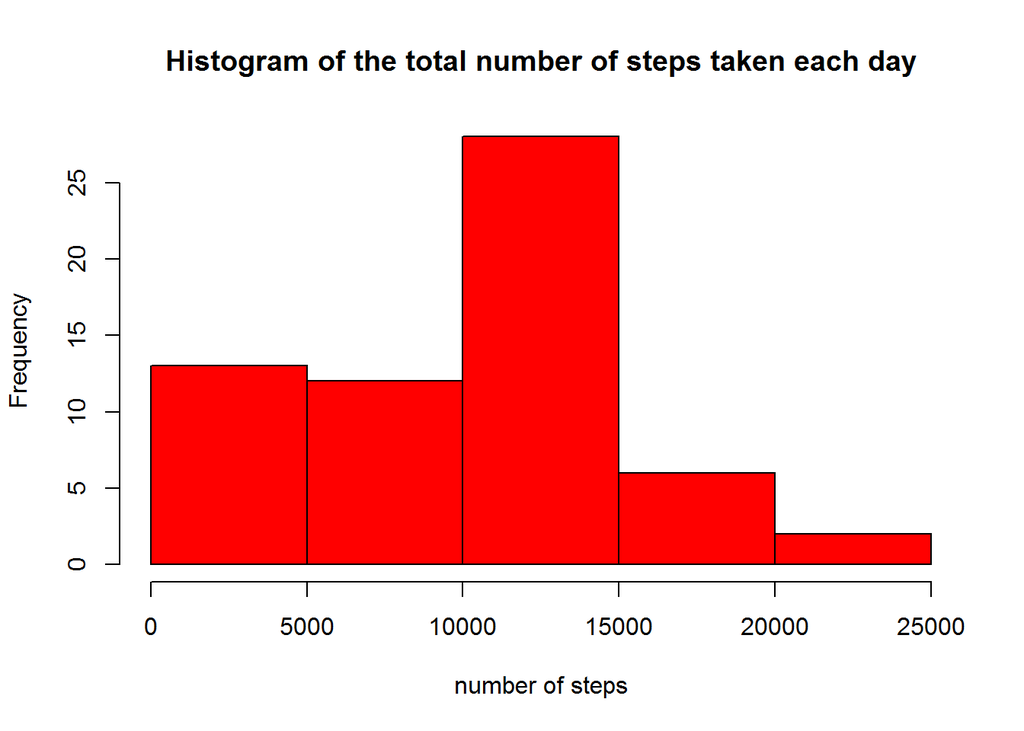

```r
hist(as(steps_date[,2],"numeric"),main = "Histogram of the total number of steps taken each day",xlab = "number of steps",col="red")
```

## Calculation of mean and median

Now let’s calculate the mean and the median of the total number of steps taken per day.

The mean is:

```r
 mean(as(steps_date[,2],"numeric"),na.rm=TRUE)
```

```
## [1] 9354
```

The median is:

```r
median(as(steps_date[,2],"numeric"), na.rm=TRUE)
```

```
## [1] 10395
```

## Average daily activity pattern

Let’s build a data frame containing 5-minute intervals and the average number of steps taken, averaged across all days.

```r
intervals<-unique(my_data$interval)
average_per_interval<-function(intervals){
        num_intervals<-length(intervals)
        my_data_records<-nrow(my_data)
        avg_vector<-numeric()
        interval_avg<-data.frame()
        check_first_if<-0
        check_second_if<-0
        check_steps<-numeric()
        for(i in 1:num_intervals){
                counter<-0
                sum_for_average<-0
                for(j in 1:my_data_records){
                        if(intervals[i]==my_data$interval[j]){
                                check_first_if<-check_first_if+1
                                if(!is.na(my_data$steps[j])){
                                        check_second_if<-check_second_if+1
                                        counter<-counter+1
                                        check_steps<-c(check_steps,my_data$steps[j])
                                        sum_for_average<-sum_for_average+my_data$steps[j]
                                }
                        }
                }
                avg<-sum_for_average/counter
                avg_vector<-c(avg_vector,avg)
        }
        interval_avg<-cbind(intervals,avg_vector)
        interval_avg
}

interval_average<-average_per_interval(intervals)
```

Now let’s make a time series plot (i.e. type = “l”) of the 5-minute interval (x-axis) and the average number of steps taken, averaged across all days (y-axis)

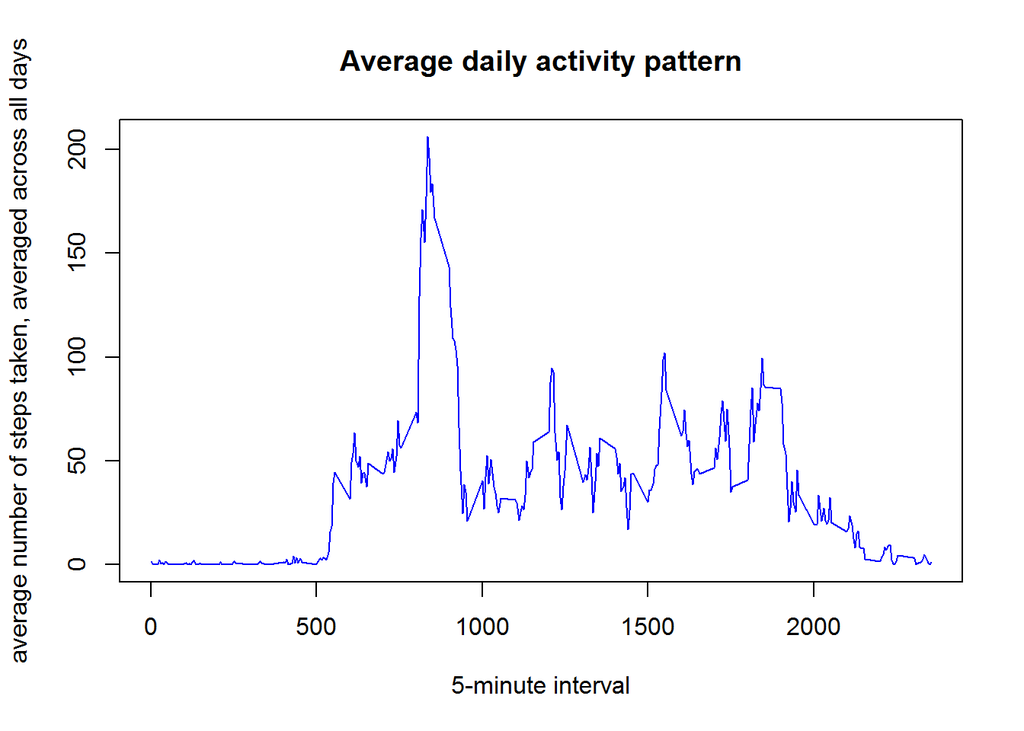

```r
plot(interval_average[,1],interval_average[,2],type="l",xlab="5-minute interval",ylab="average number of steps taken, averaged across all days",main="Average daily activity pattern",col="blue")
```

Now let’s calculate which 5-minute interval, on average across all the days in the dataset, contains the maximum number of steps:

```r
find_max<-function(interval_average){
        max<-max(interval_average[,2])
        records_num<-nrow(interval_average)
        max_interval<-NA
        for(i in 1:records_num){
                if(interval_average[i,2]==max){
                    max_interval<-interval_average[i,1]
                }
        }
        max_interval
}

maximum<-find_max(interval_average)
maximum
```

```
## intervals
##       835
```

## Imputing missing values

First let’s calculate and report the total number of missing values in the dataset (i.e. the total number of rows with NAs)

```r
find_NA<-function(my_data){
        records_num<-nrow(my_data)
        not_NA_counter<-0
        for(i in 1:records_num){
                if(!is.na(my_data[i,1])){
                        if(!is.na(my_data[i,2])){
                                if(!is.na(my_data[i,3])){
                                     not_NA_counter<-not_NA_counter+1
                                }
                        }
                }
        }
        NA_counter<-records_num-not_NA_counter
        NA_counter
}
```

The total number of rows with NAs is:

```r
NA_counter<-find_NA(my_data)
NA_counter
```

```
## [1] 2304
```

Now let’s devise a strategy for filling in all of the missing values in the dataset. We will use the mean for the 5-minute interval with NA value. Applying this strategy we may create a new dataset that is equal to the original dataset but with the missing data filled in.

```r
fill_NA<-function(my_data,interval_average){
        my_data_rows<-nrow(my_data)
        interval_average_rows<-nrow(interval_average)
        missing_interval<-NA
        missing_steps<-NA
        new_steps_vector<-numeric()
        for(i in 1:my_data_rows){
                missing_steps<-my_data[i,1]
                if(is.na(my_data[i,1])){
                        missing_interval<-my_data[i,3]
                        for(j in 1:interval_average_rows){
                                if(interval_average[j,1]==missing_interval){
                                        missing_steps<-interval_average[j,2]
                                }
                        }
                }
                new_steps_vector<-c(new_steps_vector,missing_steps)
        }
        names(new_steps_vector)<-NULL
        new_dates_vector<-my_data[,2]
        new_interval_vector<-my_data[,3]
        new_my_data<-cbind(new_steps_vector,new_dates_vector,new_interval_vector)
        new_my_data
}
new_my_data<-fill_NA(my_data, interval_average)
```

Now let’s make a histogram of the total number of steps taken each day. In order to do this we’ll use our steps_per_day function to create a data frame containing dates and numer of steps on each date.

```r
new_dates<-unique(new_my_data[,2])
new_steps_date<-steps_per_day(new_dates)
```

Now we’re ready to build the histogram.

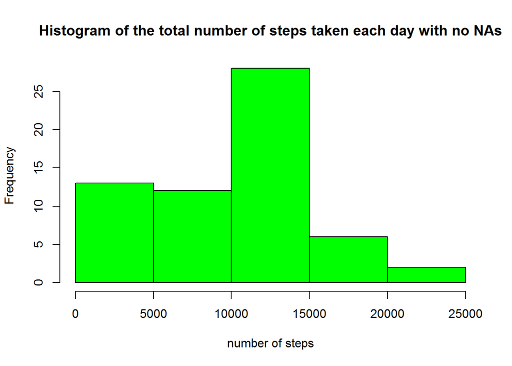

```r
hist(as(new_steps_date[,2],"numeric"),main = "Histogram of the total number of steps taken each day with no NAs",xlab = "number of steps",col="green")
```

Now let’s calculate the mean and the median of the total number of steps taken per day.

The mean is:

```r
 mean(as(new_steps_date[,2],"numeric"),na.rm=TRUE)
```

```
## [1] 9354
```

The median is:

```r
median(as(new_steps_date[,2],"numeric"), na.rm=TRUE)
```

```
## [1] 10395
```

## The differences in activity patterns between weekdays and weekends

Let’s create a new factor variable in the dataset with two levels - “weekday” and “weekend” indicating whether a given date is a weekday or weekend day.

```r
create_weekdays<-function(new_my_data){
        formatted_dates<-as.Date(new_my_data[,2])
        weekdays<-weekdays(formatted_dates)
        weekdays_records<-length(weekdays)
        day_type<-character()
        for(i in 1:weekdays_records){
                if(weekdays[i]=="Saturday"|weekdays[i]=="Sunday"){
                        day_type<-c(day_type,"weekend")
                }
                else day_type<-c(day_type,"weekday")
        }
        weekdays_new_my_data<-cbind(new_my_data,day_type=day_type)
        weekdays_new_my_data
}

weekdays_new_my_data<-create_weekdays(new_my_data)
```

Now we have to calculate the average number of steps taken, averaged across all weekday days or weekend days. For this purpose we may use our average_per_interval function.

```r
weekend_subset<-subset(weekdays_new_my_data,weekdays_new_my_data[,4]=="weekend")
weekend_intervals<-unique(weekend_subset[,3])
weekday_subset<-subset(weekdays_new_my_data,weekdays_new_my_data[,4]=="weekday")
weekday_intervals<-unique(weekday_subset[,3])
weekend_interval_average<-average_per_interval(weekend_intervals)
weekday_interval_average<-average_per_interval(weekday_intervals)
```

Now we’re ready to build the plots:

[figure not shown]

```r
par(mfrow=c(2,1))
 plot(weekday_interval_average[,1],weekday_interval_average[,2],type="l",xlab="5-minute interval",ylab="Num of steps",main="Weekday average daily activity pattern",col="blue")
plot(weekend_interval_average[,1],weekend_interval_average[,2],type="l",xlab="5-minute interval",ylab="Num of steps",main="Weekend average daily activity pattern",col="blue")
```